# install.packages

#### install.packages

```r
install.packages("latticeExtra")
install.packages("ggplot2")
install.packages("reshape2")
install.packages("PerformanceAnalytics")
install.packages("quantmod")
# install.packages('xtsExtra')
install.packages("xtsExtra_0.0-1.zip", repos = NULL)
install.packages("timeSeries")
# googleVis require(RJSONIO) install.packages('googleVis')
```

#### require.packages

```r
require(latticeExtra)
require(ggplot2)
require(reshape2)
suppressPackageStartupMessages(require(googleVis))
require(quantmod)
require(PerformanceAnalytics)
require(xtsExtra)
require(timeSeries)
```

#### options

```r
# {r echo = F, message = F, cache = F}
options(RCHART_WIDTH = 600, RCHART_HEIGHT = 400)
knitr::opts_chunk$set(comment = NA, results = "asis", tidy = F, error = T, message = F,
    warning = F, fig.width = 8, fig.height = 5, fig.keep = "last")
```

```r
# {r echo = F, message = F, cache = F}
knitr::opts_chunk$set(results = "asis", tidy = F, error = T, message = F, warning = F,
    fig.width = 8, fig.height = 5)
```

# History of R Financial Time Series Plotting

For a much more extensive discussion of time series analysis with R, please see:

- [Time Series Analysis with R](http://www.stats.uwo.ca/faculty/aim/tsar/tsar.pdf) by A. Ian McLeod, Hao Yu, and Esam Mahdi
- [CRAN Task View: Time Series Analysis](http://cran.r-project.org/web/views/TimeSeries.html) by Rob Hyndman
- [A Little Book of R for Time Series](http://a-little-book-of-r-for-time-series.readthedocs.org/en/latest/src/timeseries.html) by Avril Chohlan
- [`getSymbols()`](https://r-forge.r-project.org/scm/viewvc.php/pkg/R/getSymbols.R?root=quantmod&view=log)
- [`rCharts`](http://ramnathv.github.io/rCharts)

#### Получаем данные

```r
require(quantmod)
# get S&P 500 data from FRED (St. Louis Fed)
sp500 <- na.omit(
  getSymbols(
    "SP500",
    src = "FRED",
    from = "1949-12-31",
    auto.assign = FALSE
  )
)
head(sp500)
```

```
       SP500
```

1957-01-02 46.20 1957-01-03 46.60 1957-01-04 46.66 1957-01-07 46.42 1957-01-08 46.25 1957-01-09 46.16

```r
# use monthly data
sp500.monthly <- sp500[endpoints(sp500, on ="months")]
```

#### Подготавливаем данные

```r
# base plot of time series prior to xts
# get the data in data.frame format rather than xts
sp500.df <- data.frame(
  index(sp500.monthly),
  coredata(sp500.monthly),
  stringsAsFactors=FALSE
)
# name columns
colnames( sp500.df ) <- c( "date", "sp500" )
head(sp500.df)
```

```
    date sp500
```

1 1957-01-31 44.72 2 1957-02-28 43.26 3 1957-03-29 44.11 4 1957-04-30 45.74 5 1957-05-31 47.43 6 1957-06-28 47.37

### `plot.default` (As Old as Time Itself)

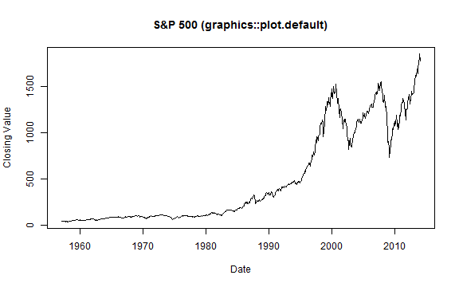

```r
# go back in time to plot.default from the graphics library
graphics::plot.default(
  x = sp500.df$date,
  y = sp500.df$sp500,
  type = "l",
  xlab = "Date",
  ylab = "Closing Value",
  main = "S&P 500 (graphics::plot.default)"
)
```

### [`ts`](https://stat.ethz.ch/pipermail/r-announce/1999/000097.html) 1999-08-27

The `ts` package was added in R version 0.65.0 and significantly improved with release 1.5.0 in April 2002. There is a very good discussion of the improvements in Brian Ripley's [“Time Series in R 1.5.0” from Volume 2 of R News, June 2002](http://cran.r-project.org/doc/Rnews/Rnews_2002-2.pdf). `plot.ts()` added some nice features, such as the ability to plot multiple/wide time series, specify panels per series, and easily calculate acf, ARIMA,and HoltWinters.

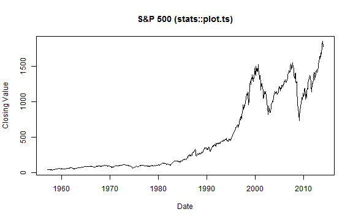

```r
stats::plot.ts(
  ts(sp500.monthly,
     start = c(
       as.numeric(format(index(sp500.monthly)[1],"%Y")),
       as.numeric(format(index(sp500.monthly)[1],"%m"))
     ),
     frequency = 12
  ), # some backwards conversion to ts from xts
  xlab = "Date",
  ylab = "Closing Value",
  main = "S&P 500 (stats::plot.ts)"
)
```

### [`lattice`](http://r-forge.r-project.org/scm/?group_id=638) and [`grid`](http://www.stat.auckland.ac.nz/%7Epaul/grid/grid.html) released with R 1.5.0 2002-04-29

R 1.5.0 was a very important milestone for both graphing and time series analysis with the release of `lattice` (Deepayan Sarkar) and `gri`d (Paul Murrell) and also the improvements in `ts` mentioned above., All of these are covered in [Volume 2 of R News, June 2002](http://cran.r-project.org/doc/Rnews/Rnews_2002-2.pdf). `lattice` using `grid` as its platform began an era of aesthetically pleasing and production-quality graphics straight from R.

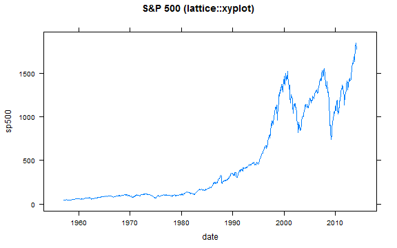

```r
#install.packages("lattice")
require("lattice")
xyplot(
  sp500 ~ date,
  data = sp500.df,
  type = "l",
  main = "S&P 500 (lattice::xyplot)"
)
```

### [zoo](https://r-forge.r-project.org/scm/viewvc.php/pkg/zoo/R/plot.zoo.R?root=zoo&view=log) 2004-10-08

`zoo` made it easier to work with irregular time series in R and “bridged the gap.” `plot.zoo()` allowed us `plot.ts()` functionality for zoo objects.

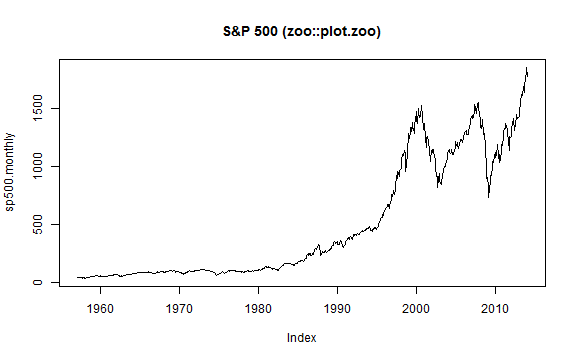

```r
zoo::plot.zoo(
  sp500.monthly,
  main = "S&P 500 (zoo::plot.zoo)"
)
```

### [`zoo`](https://r-forge.r-project.org/scm/viewvc.php/pkg/zoo/R/xyplot.zoo.R?root=zoo&view=log) Meets [`lattice`](http://r-forge.r-project.org/scm/?group_id=638) 2006-07-06

`zoo` adds a very handy `xyplot.zoo()` function so there is no more need to convert `zoo` objects before accessing all the power off `lattice`.

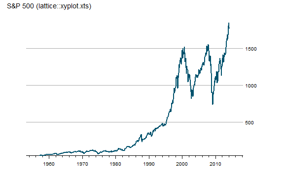

```r
# although slightly out of chronology
# I'll also use theEconomist from latticeExtra
#install.packages('latticeExtra')
require(latticeExtra)
asTheEconomist(
  xyplot(
    sp500.monthly,
    scales = list( y = list( rot = 0 ) ),
    main = "S&P 500 (lattice::xyplot.xts)"
  )
)
```

### [`PerformanceAnalytics` `chart.TimeSerie`s](https://r-forge.r-project.org/scm/viewvc.php/pkg/PerformanceAnalytics/R/chart.TimeSeries.R?root=returnanalytics&view=log) 2007-02-02

`PerformanceAnalytics` addressed many of the graphical patterns necessary for financial performance reporting. `chart.TimeSeries()` and `chart.BarVaR()` serve as the base for functions such as the very useful `charts.PerformanceSummary()` below. In addition to the charts, `PerformanceAnalytics` adds many useful tables and makes both easy and very complicated performance calculations accessible in R. Most of the `PerformanceAnalytics` functions require a `xts` return series rather than price.

#### 2007-02-02 chart.TimeSeries in PerformanceAnalytics

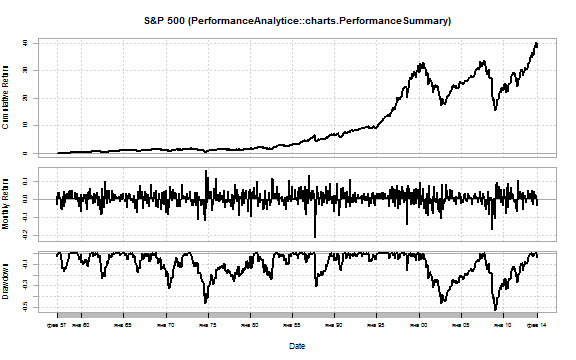

```r
#install.packages('PerformanceAnalytics')
require(PerformanceAnalytics)
# "S&P 500 (PerformanceAnalytice::charts.PerformanceSummary)"
charts.PerformanceSummary(
  ROC(sp500.monthly, n = 1, type = "discrete"),
  main = "S&P 500 (PerformanceAnalytice::charts.PerformanceSummary)"
)
```

### [`ggplot2`](http://cran.r-project.org/src/contrib/Archive/ggplot2/) 2007-06-10

Hadley Wickham's 2005 original `ggplot` was significant, but the [2007 rewrite into `ggplot2` 0.5](http://comments.gmane.org/gmane.comp.lang.r.general/86781) completely changed R graphics. Although `ggplot2` is comprehensive and not designed specifically for time series plotting, I include it in the timeline due to both its significant impact on R graphics and its ability to handle dates/times on the x-axis. To use xts with `ggplot2`, a simple conversion to a wide or long format data.frame is necessary.

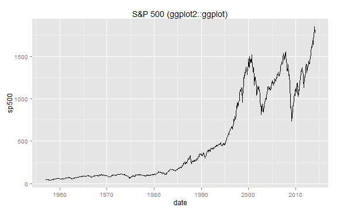

```r
#ggplot2 requires conversion of xts to data.frame
#we will use the data.frame from the plot.default example
#install.packages('ggplot2')
require(ggplot2)
ggplot( sp500.df, aes(date) ) +
  geom_line( aes( y = sp500 ) ) +
  labs( title = "S&P 500 (ggplot2::ggplot)")
```

### [`quantmod`/`TTR` `chartSeries`](https://r-forge.r-project.org/scm/viewvc.php/pkg/R/chartSeries.R?root=quantmod&view=log) 2007-10-07

`quantmod` and `TTR` were designed to give R technical analysis tools and calculations. The `chartSeries()` function makes OHLC, candlesticks, and bars charts of prices easy. Adding technical analysis, such as Bollinger Bands, RSI, MACD, becomes a couple letter function.

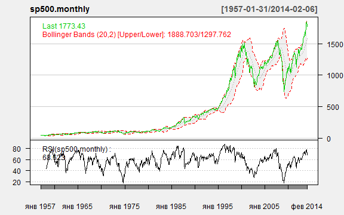

```r
require(quantmod)
chartSeries(
  sp500.monthly,
  theme = chartTheme("white"),
  TA = c(addBBands(),addTA(RSI(sp500.monthly)))
)
```

Just look how easy it is to zoom.

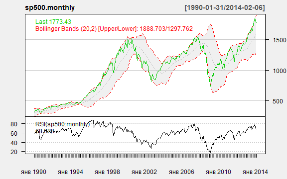

```r
# also easy zooming
zoomChart("1990::")
```

### [`xts` `plot.xts`](https://r-forge.r-project.org/scm/viewvc.php/pkg/xts/R/plot.R?root=xts&view=log) 2008-02-17

In 2008, despite the various time series options in R, the world of finance demanded more and Jeff Ryan and Joshua Ulrich responded with `xts`. I strongly recommend reading the [`xts` vignette](http://cran.r-project.org/web/packages/xts/vignettes/xts.pdf) to understand the benefits of `xts`. It is now the standard for financial time series in R. `xts` ported `plot.zoo()` to its own `plot()` method. A `xyplot.xts()` was also provided for use with `lattice`.

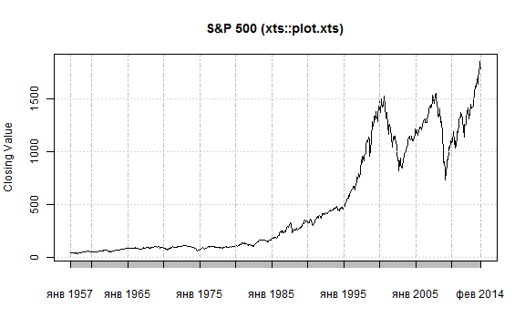

```r
# 2008-02-17 xts improved zoo and other time series libraries
# http://cran.r-project.org/web/packages/xts/vignettes/xts.pdf
# plot.zoo got ported to plot.xts and little graphing improvement
xts::plot.xts(
  sp500.monthly,
  ylab = "Closing Value",
  main = "S&P 500 (xts::plot.xts)"
)
```

### [`timeSeries` `plot`](https://r-forge.r-project.org/scm/viewvc.php/pkg/timeSeries/R/methods-plot.R?root=rmetrics&view=log) 2009-05-17

The `timeSeries` `plot()` method is basically a port of R's `plot.ts()`. It does not significantly add any plotting functionality, but I include it for completeness and since the [Rmetrics team](https://www.rmetrics.org) offers robust financial analysis through its many R packages that depend on the `timeSeries` object.

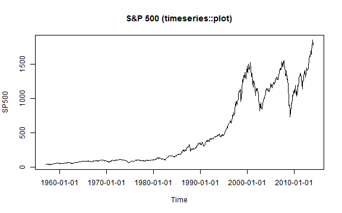

```r
#install.packages("timeSeries")
require(timeSeries)
timeSeries::plot(
  timeSeries(sp500.monthly),
  main = "S&P 500 (timeseries::plot)"
)
```

### [`googleVis`](http://cran.r-project.org/src/contrib/Archive/googleVis/) 2010-11-30 and [source](https://code.google.com/p/google-motion-charts-with-r/)

`googleVis` adds accessible interactivity to charts using [Google Charts](https://developers.google.com/chart/interactive/docs/index). There are a variety of chart types along with very nice animation/storyboard options.

```r
suppressPackageStartupMessages(require(googleVis))
g1 <- gvisLineChart(
  data = sp500.df,
  xvar = "date",
  yvar = "sp500",
  options = list(
    title = "S&P 500 (googleVis::gvisLineChart)",
    height = 400,
    width = 600
  )
)
#plot googleVis gvisLineChart
#plot(g1)
g1
```

[output not shown]

### [xtsExtra plot.xts and barplot.xts](https://r-forge.r-project.org/scm/viewvc.php/pkg/xtsExtra/R/plot.R?root=xts&view=log) 2012-05-30

The Summer 2012 Google Summer of Code project `xtsExtra` by Michael Weylandt sought to improve the `xts` plotting methods as described well in [Michael's announcement to R-Sig-Finance](https://stat.ethz.ch/pipermail/r-sig-finance/2012q3/010652.html). [lots of examples in this post](http://timelyportfolio.blogspot.com/search/label/plot.xts).

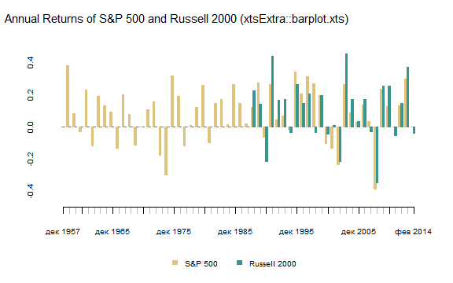

```r
#install.packages('xtsExtra')
#install.packages('xtsExtra', source = "http://r-forge.r-project.org")
#Warning in install.packages :
#  package ‘xtsExtra’ is not available (for R version 3.0.2)
#install.packages("xtsExtra_0.0-1.zip", repos = NULL)
require(xtsExtra)
#explore barplot.xts to do a chart of annual returns for both indexes
#merge prices
russell2000 <- getSymbols("^RUT", from = "1900-01-01", auto.assign = F)
prices <- merge(sp500,russell2000[,4])
#use endpoints to get annual returns
returns.annual <- as.xts(
  apply(
    ROC(prices[endpoints(prices,"years")],type="discrete",n=1),
    MARGIN = 2,
    FUN = na.fill, fill = 0
  ),
  order.by = index(prices[endpoints(prices,"years")])
)
#name columns something a little more clear
colnames(returns.annual) <- c("S&P 500","Russell 2000")

barplot.xts(
  returns.annual,
  stacked=FALSE,
  box="transparent",  #get rid of box surrounding the plot
  ylim=c(-0.5,0.5),
  ylab=NA,
  border=c(brewer.pal(n=11,"BrBG")[c(4,9)]),
  col=c(brewer.pal(n=11,"BrBG")[c(4,9)])
)

title(
  main="Annual Returns of S&P 500 and Russell 2000 (xtsExtra::barplot.xts)",
  outer = TRUE,
  adj=0.05,
  font.main = 1,
  cex.main = 1.25,
  line = -2
)
```

### `zoo` meets `ggplot2` with [`autoplot.zoo()`](https://r-forge.r-project.org/scm/viewvc.php/pkg/zoo/R/ggplot2.zoo.R?view=markup&revision=939&root=zoo) 2012-10-14

Similar to `zoo` meets `lattice` above, `autoplot.zoo()` makes plotting `zoo` with `ggplot2` much easier. As the codes shows below, `xts` can also use `autoplot.zoo()` with no explicit transformation.

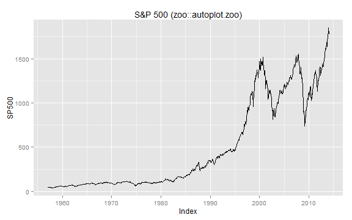

```r
autoplot.zoo(sp500.monthly) +
  ggtitle("S&P 500 (zoo::autoplot.zoo)")
```

## Thanks

Thanks to all the wonderful and diligent contributors who have made R great.

## References

- http://www.stats.uwo.ca/faculty/aim/tsar/tsar.pdf
- http://cran.r-project.org/web/views/TimeSeries.html
- http://cran.r-project.org/web/packages/zoo/vignettes/zoo.pdf
- http://cran.r-project.org/web/packages/timeSeries/timeSeries.pdf
- http://cran.r-project.org/web/packages/xts/vignettes/xts.pdf
- http://fishyoperations.com/r/timeline-graph-with-ggplot2/